# Results_No_Random_Lunar_Rerun

Sean Dimoff

25/05/20

**Exploratory Plots for 2017-2018 Acoustic/Fish Data**

**Purpose** To rerun my models with local disturbance as a continuous variable, year as a categorical variable, and lunar phase as a categorical variable.

I have summarized results at the top here, but please scroll down if you would like to see the outputs of the linear models and further analysis into each of the selected models, how they compare with my results when I included random effects, and comparisons between “matching” models if the new selected models aren’t the same as those selected when random effects were included.

*Note*

Any models that use MF - are actually my low frequency models - this is just an artifact from the beginning of the project.

fishing pressure has now been centered.

In the low frequencies, Lunar phase category “First Quarter” cannot be analyzed because it is the only category of lunar phase in 2018 and therefore they are collinear.

# Results Summarized

**Overview:**

SPL -

HF SPL - Lunar phase is at all levels significant, but the model doesn’t explain any more variation than when lunar phase wasn’t included.

LF SPL - Lunar phase is not significant, and the model only explains .1% more variation than the same model without lunar phase.

ACI -

HF ACI - Lunar phase is only significant in the new phase (full is the baseline). This model only explains 0.5% more variation than a model without lunar phase.

**Plots Overview**

SPL -

SPL increases in both the HF and LF during new and quarter moons, but there don’t appear to be corresponding increases in our explanatory variables (knocks, long calls, herbivory) - even when I subset for only night recordings.

Interestingly, the first quarter lunar phase is the only phase from 2018 AND it didn’t occur in 2017. However, it’s peaks seem to be nearly the same as New moon peaks from 2017. Potentially indicating that some of the variation attributed to year is actually just an artifact of lunar phase… Although I don’t think we have the evidence to say anything conclusive about it.

ACI -

ACI doesn’t appear to be affected by lunar cycle at all.

# Models

## SPL HF Model

### Model Selection

```r
#coming up with several variations on the models presented above

#testing each of the models

splhftbl <- AICc(simple.model, simple.model1, simple.model2, simple.model4, simple.model5)

splhftbl$minAIC <- 77762.48
splhftbl$deltaAIC <- splhftbl$AICc - splhftbl$minAIC

splhftbl
```

```
##               df     AICc   minAIC     deltaAIC
## simple.model   8 79674.07 77762.48 1.911595e+03
## simple.model1  8 78675.61 77762.48 9.131294e+02
## simple.model2  9 77869.37 77762.48 1.068883e+02
## simple.model4 10 77762.48 77762.48 2.696634e-03
## simple.model5 11 78049.92 77762.48 2.874412e+02
```

```r
summary(simple.model4)
```

```
##
## Call:
## lm(formula = SPL_HF ~ Snaps * dn + fp.cont + Year + lunar.phase,
##     data = Snap.HF)
##
## Residuals:
##     Min      1Q  Median      3Q     Max
## -8.8168 -1.7779 -0.0788  1.7897 12.5316
##
## Coefficients:
##                            Estimate Std. Error t value Pr(>|t|)
## (Intercept)               1.041e+02  7.004e-01 148.655  < 2e-16 ***
## Snaps                     7.160e-03  4.807e-04  14.894  < 2e-16 ***
## dnNight                  -9.395e+00  1.085e+00  -8.657  < 2e-16 ***
## fp.cont                   1.001e+00  4.475e-02  22.366  < 2e-16 ***
## Year2018                  3.152e+00  6.985e-02  45.129  < 2e-16 ***
## lunar.phaseNew            7.864e-01  6.370e-02  12.345  < 2e-16 ***
## lunar.phaseThird Quarter  5.650e-01  5.950e-02   9.495  < 2e-16 ***
## lunar.phaseFirst Quarter  6.778e-01  8.509e-02   7.966 1.74e-15 ***
## Snaps:dnNight             7.753e-03  7.419e-04  10.450  < 2e-16 ***
## ---
## Signif. codes:  0 '***' 0.001 '**' 0.01 '*' 0.05 '.' 0.1 ' ' 1
##
## Residual standard error: 2.753 on 15978 degrees of freedom
## Multiple R-squared:  0.378,  Adjusted R-squared:  0.3777
## F-statistic:  1214 on 8 and 15978 DF,  p-value: < 2.2e-16
```

**Same model is picked as when random effects are included**

All phases of the moon are significant - the full moon is the baseline.

This model explains about 37% of the variation in high frequency SPL - same as when lunar phase wasn’t included.

## ACI HF Model

### Model Selection

```r
acihftbl <- AICc(aci.hf, aci.hf1a, aci.hf2, aci.hf4)

acihftbl$minAIC <- 319640.0
acihftbl$deltaAIC <- acihftbl$AICc - acihftbl$minAIC

acihftbl
```

```
##          df     AICc minAIC     deltaAIC
## aci.hf    8 319641.5 319640   1.49499132
## aci.hf1a  8 319925.0 319640 284.97952962
## aci.hf2   9 319640.8 319640   0.79723629
## aci.hf4  10 319640.0 319640  -0.04698465
```

**This is not the same model as when we included random effects**

The most parsimonious model here is aci.hf.

```r
summary(aci.hf)
```

```
##
## Call:
## lm(formula = ACI_HF ~ Snaps + fp.cont + Year + lunar.phase, data = Snap.HF)
##
## Residuals:
##      Min       1Q   Median       3Q      Max
## -12529.3  -3866.6   -914.1   3083.0  21433.6
##
## Coefficients:
##                            Estimate Std. Error t value Pr(>|t|)
## (Intercept)              81432.1647  1012.8612  80.398  < 2e-16 ***
## Snaps                      -11.7127     0.6921 -16.924  < 2e-16 ***
## fp.cont                  -2452.8661    84.8928 -28.894  < 2e-16 ***
## Year2018                  -332.4350   134.4951  -2.472  0.01346 *
## lunar.phaseNew             329.5936   122.8908   2.682  0.00733 **
## lunar.phaseThird Quarter  -143.3233   114.7656  -1.249  0.21174
## lunar.phaseFirst Quarter   197.1844   164.1359   1.201  0.22963
## ---
## Signif. codes:  0 '***' 0.001 '**' 0.01 '*' 0.05 '.' 0.1 ' ' 1
##
## Residual standard error: 5312 on 15980 degrees of freedom
## Multiple R-squared:  0.07538,    Adjusted R-squared:  0.07503
## F-statistic: 217.1 on 6 and 15980 DF,  p-value: < 2.2e-16
```

However, it only explains about 7.5% of the variation in ACI. A .5% increase from when lunar phase wasn’t included.

Year is now signiciant, although with a small effect size for ACI (-332)

When random effects were included we chose the model that included an interaction between snaps and day/night. The summary for the “matching” model without random effects is below

```r
summary(aci.hf4)
```

```
##
## Call:
## lm(formula = ACI_HF ~ Snaps * dn + fp.cont + Year + lunar.phase,
##     data = Snap.HF)
##
## Residuals:
##      Min       1Q   Median       3Q      Max
## -12512.8  -3872.8   -913.9   3076.1  21523.0
##
## Coefficients:
##                            Estimate Std. Error t value Pr(>|t|)
## (Intercept)              83099.4419  1351.1886  61.501  < 2e-16 ***
## Snaps                      -12.9012     0.9274 -13.911  < 2e-16 ***
## dnNight                  -3388.6240  2093.5351  -1.619  0.10555
## fp.cont                  -2423.3242    86.3364 -28.068  < 2e-16 ***
## Year2018                  -343.1327   134.7412  -2.547  0.01089 *
## lunar.phaseNew             327.8132   122.8832   2.668  0.00765 **
## lunar.phaseThird Quarter  -146.3195   114.7915  -1.275  0.20245
## lunar.phaseFirst Quarter   198.8959   164.1436   1.212  0.22564
## Snaps:dnNight                2.4142     1.4312   1.687  0.09166 .
## ---
## Signif. codes:  0 '***' 0.001 '**' 0.01 '*' 0.05 '.' 0.1 ' ' 1
##
## Residual standard error: 5311 on 15978 degrees of freedom
## Multiple R-squared:  0.0757, Adjusted R-squared:  0.07524
## F-statistic: 163.6 on 8 and 15978 DF,  p-value: < 2.2e-16
```

Snaps is also significant but there is no significant change in their effect on ACI between day and night.

This model explains only about 7.5% of variation in HF ACI as well.

## LF SPL Model

### Model Selection

```r
splmftbl <- AICc(simple1amf, simple1bmf, simple1cmf, simple2amf, simple2bmf, simple2cmf, simple3mf, simple4mf, simple6amf, simple6bmf, simple7mf, reducemf3, reducemf4, reducemf6, reducemf7)

splmftbl$minAIC <- 883.3541
splmftbl$deltaAIC <- splmftbl$AICc - splmftbl$minAIC

splmftbl
```

```
##            df     AICc   minAIC      deltaAIC
## simple1amf  7 937.8135 883.3541  5.445940e+01
## simple1bmf  7 952.1179 883.3541  6.876381e+01
## simple1cmf  7 950.6168 883.3541  6.726274e+01
## simple2amf  8 936.5295 883.3541  5.317538e+01
## simple2bmf  8 939.0378 883.3541  5.568369e+01
## simple2cmf  9 938.1002 883.3541  5.474607e+01
## simple3mf  12 928.8503 883.3541  4.549621e+01
## simple4mf  15 885.1906 883.3541  1.836516e+00
## simple6amf 18 887.3272 883.3541  3.973127e+00
## simple6bmf 18 883.3541 883.3541 -3.227311e-05
## simple7mf  21 883.8734 883.3541  5.192709e-01
## reducemf3  10 929.7949 883.3541  4.644077e+01
## reducemf4  13 892.4673 883.3541  9.113210e+00
## reducemf6  14 884.2964 883.3541  9.423007e-01
## reducemf7  14 926.0941 883.3541  4.274004e+01
```

```r
splmftbl.short <- subset(splmftbl, deltaAIC < 6)

splmftbl.short
```

```
##            df     AICc   minAIC      deltaAIC
## simple4mf  15 885.1906 883.3541  1.836516e+00
## simple6amf 18 887.3272 883.3541  3.973127e+00
## simple6bmf 18 883.3541 883.3541 -3.227311e-05
## simple7mf  21 883.8734 883.3541  5.192709e-01
## reducemf6  14 884.2964 883.3541  9.423007e-01
```

I think here reducemf6 is the most respresentative model - it is the most parsimonious model in the end, but also explains roughly the same amount of variation in the response variable.

reducemf6: MF SPL ~ (Knocks * Hour) + Herbivory + Hour + Year + fp.cont + lunar.phase

```r
summary(reducemf6)
```

```
##
## Call:
## lm(formula = SPL_Midrange ~ Tot_Knocks + Hour + Tot_Knocks:Hour +
##     Num_Herbivory + fp.cont + Year + lunar.phase, data = AC.DF1Co)
##
## Residuals:
##     Min      1Q  Median      3Q     Max
## -5.6546 -1.5522 -0.1696  1.2191  6.3358
##
## Coefficients: (1 not defined because of singularities)
##                          Estimate Std. Error t value Pr(>|t|)
## (Intercept)              102.4494     0.5120 200.089  < 2e-16 ***
## Tot_Knocks                -1.8945     1.0683  -1.773 0.077884 .
## Hour21                     1.4860     0.5667   2.622 0.009489 **
## Hour3                      0.4436     0.5849   0.758 0.449184
## Hour9                      2.1966     0.5889   3.730 0.000257 ***
## Num_Herbivory              1.2484     0.3936   3.172 0.001785 **
## fp.cont                   -0.3899     0.3882  -1.004 0.316504
## Year18                     3.7090     0.4113   9.017 3.02e-16 ***
## lunar.phaseNew             0.4282     0.5915   0.724 0.470025
## lunar.phaseThird Quarter   0.7079     0.5045   1.403 0.162266
## lunar.phaseFirst Quarter       NA         NA      NA       NA
## Tot_Knocks:Hour21          2.1532     1.2398   1.737 0.084150 .
## Tot_Knocks:Hour3           2.4321     1.2182   1.996 0.047415 *
## Tot_Knocks:Hour9           7.3429     1.2276   5.982 1.18e-08 ***
## ---
## Signif. codes:  0 '***' 0.001 '**' 0.01 '*' 0.05 '.' 0.1 ' ' 1
##
## Residual standard error: 2.344 on 178 degrees of freedom
## Multiple R-squared:  0.5667, Adjusted R-squared:  0.5375
## F-statistic:  19.4 on 12 and 178 DF,  p-value: < 2.2e-16
```

Explains 53.7% of variation in MF SPL. Without lunar phase explained 53.6%.

Lunar.phasefirst quarter is coming up NA here, which means that “…it is linearly related to another variable…” which is year because first quarter is what every sampling day in 2018 was categorized as.

**This is not the same model selected as when we included random effects**

That model did not include herbivory.

fishing pressure is not significant. Year is significant and 2018 is 3.7 dB louder than 2017.

The interaction between knocks and 9AM is still significant and positive.

simple7mf: MF SPL ~ (Knocks + Herbivory + Long Calls) * Hour + Year + fp.cont + lunar.phase

```r
summary(simple7mf)
```

```
##
## Call:
## lm(formula = SPL_Midrange ~ Tot_Knocks + Num_Herbivory + Num_L_calls +
##     Hour + fp.cont + Year + Tot_Knocks:Hour + Num_Herbivory:Hour +
##     Num_L_calls:Hour + lunar.phase, data = AC.DF1Co)
##
## Residuals:
##     Min      1Q  Median      3Q     Max
## -4.8528 -1.3793 -0.1511  1.3052  6.1076
##
## Coefficients: (1 not defined because of singularities)
##                          Estimate Std. Error t value Pr(>|t|)
## (Intercept)              102.2354     0.5106 200.211  < 2e-16 ***
## Tot_Knocks                -1.8828     1.0481  -1.796 0.074211 .
## Num_Herbivory              1.5236     0.4084   3.731 0.000259 ***
## Num_L_calls               -0.9724     1.3468  -0.722 0.471296
## Hour21                     1.3353     0.5771   2.314 0.021874 *
## Hour3                     -2.3725     2.2674  -1.046 0.296888
## Hour9                      2.7614     2.1678   1.274 0.204461
## fp.cont                   -0.1414     0.4062  -0.348 0.728120
## Year18                     3.8207     0.4108   9.300  < 2e-16 ***
## lunar.phaseNew             0.3025     0.5810   0.521 0.603253
## lunar.phaseThird Quarter   0.7771     0.5034   1.544 0.124510
## lunar.phaseFirst Quarter       NA         NA      NA       NA
## Tot_Knocks:Hour21          2.8647     1.2422   2.306 0.022296 *
## Tot_Knocks:Hour3           2.5052     1.1925   2.101 0.037132 *
## Tot_Knocks:Hour9           7.0962     1.2202   5.816  2.9e-08 ***
## Num_Herbivory:Hour21      -2.6140     1.2478  -2.095 0.037645 *
## Num_Herbivory:Hour3      -17.0829    12.5836  -1.358 0.176395
## Num_Herbivory:Hour9        4.9640    12.3073   0.403 0.687203
## Num_L_calls:Hour21         2.0595     1.4067   1.464 0.145025
## Num_L_calls:Hour3          0.1997     1.7650   0.113 0.910062
## Num_L_calls:Hour9         -2.1975     2.0260  -1.085 0.279620
## ---
## Signif. codes:  0 '***' 0.001 '**' 0.01 '*' 0.05 '.' 0.1 ' ' 1
##
## Residual standard error: 2.284 on 171 degrees of freedom
## Multiple R-squared:  0.6046, Adjusted R-squared:  0.5607
## F-statistic: 13.76 on 19 and 171 DF,  p-value: < 2.2e-16
```

Adds 7 df, but only increases AIC by .5 Explains 56% of variation in MF SPL.

Lunar phase still not significant.

Our matching model - the one that is the same as the chosen model in our results that included a random effect is below.

```r
summary(reducemf4)
```

```
##
## Call:
## lm(formula = SPL_Midrange ~ Tot_Knocks + Hour + Tot_Knocks:Hour +
##     fp.cont + Year + lunar.phase, data = AC.DF1Co)
##
## Residuals:
##     Min      1Q  Median      3Q     Max
## -5.0810 -1.6192 -0.2226  1.1648  7.5801
##
## Coefficients: (1 not defined because of singularities)
##                          Estimate Std. Error t value Pr(>|t|)
## (Intercept)              102.9958     0.4942 208.400  < 2e-16 ***
## Tot_Knocks                -1.3031     1.0782  -1.209   0.2284
## Hour21                     0.9111     0.5503   1.656   0.0996 .
## Hour3                     -0.3422     0.5431  -0.630   0.5294
## Hour9                      1.4104     0.5475   2.576   0.0108 *
## fp.cont                   -0.5979     0.3922  -1.525   0.1291
## Year18                     3.7330     0.4215   8.856 8.03e-16 ***
## lunar.phaseNew             0.4251     0.6063   0.701   0.4841
## lunar.phaseThird Quarter   0.7921     0.5164   1.534   0.1268
## lunar.phaseFirst Quarter       NA         NA      NA       NA
## Tot_Knocks:Hour21          1.6858     1.2617   1.336   0.1832
## Tot_Knocks:Hour3           1.7562     1.2294   1.428   0.1549
## Tot_Knocks:Hour9           6.6618     1.2388   5.377 2.34e-07 ***
## ---
## Signif. codes:  0 '***' 0.001 '**' 0.01 '*' 0.05 '.' 0.1 ' ' 1
##
## Residual standard error: 2.402 on 179 degrees of freedom
## Multiple R-squared:  0.5422, Adjusted R-squared:  0.514
## F-statistic: 19.27 on 11 and 179 DF,  p-value: < 2.2e-16
```

Lunar phase is not significant.

fishing pressure is not significant.

Year is significant - 2018 is ~3.5 dB louder than 2017.

## LF ACI Model

### Model Selection

```r
acimftbl <-AICc(mf.aci1, mf.aci2a, mf.aci2b, mf.aci3, mf.aci4, fit.mfaci6, fit.mfaci7, mf.maxaci, mf.acil, mf.acih, mf.acilh, mf.acihh)

acimftbl$minAIC <- 4056.976
acimftbl$deltaAIC <- acimftbl$AICc - acimftbl$minAIC

acimftbl
```

```
##            df     AICc   minAIC      deltaAIC
## mf.aci1     7 4056.976 4056.976 -0.0001465029
## mf.aci2a    8 4057.888 4056.976  0.9115020873
## mf.aci2b    8 4058.752 4056.976  1.7762065242
## mf.aci3     9 4059.818 4056.976  2.8421100277
## mf.aci4    10 4060.750 4056.976  3.7742804587
## fit.mfaci6 12 4063.800 4056.976  6.8238979921
## fit.mfaci7 15 4070.646 4056.976 13.6698118059
## mf.maxaci  21 4080.034 4056.976 23.0582018133
## mf.acil     7 4061.261 4056.976  4.2853900938
## mf.acih     7 4060.698 4056.976  3.7224558041
## mf.acilh   13 4071.036 4056.976 14.0601088618
## mf.acihh   13 4069.445 4056.976 12.4687082572
```

```r
acimftbl.short <- subset(acimftbl, deltaAIC < 6)

acimftbl.short
```

```
##          df     AICc   minAIC      deltaAIC
## mf.aci1   7 4056.976 4056.976 -0.0001465029
## mf.aci2a  8 4057.888 4056.976  0.9115020873
## mf.aci2b  8 4058.752 4056.976  1.7762065242
## mf.aci3   9 4059.818 4056.976  2.8421100277
## mf.aci4  10 4060.750 4056.976  3.7742804587
## mf.acil   7 4061.261 4056.976  4.2853900938
## mf.acih   7 4060.698 4056.976  3.7224558041
```

**The selected model is different from the selected model including random effects**

The model with the lowest AIC here is my simplest model including only knocks, fishing pressure, year, and lunar phase.

```r
summary(mf.aci1)
```

```
##
## Call:
## lm(formula = ACI_Midrange ~ Tot_Knocks + fp.cont + Year + lunar.phase,
##     data = AC.DF1Co)
##
## Residuals:
##    Min     1Q Median     3Q    Max
## -14439  -7672  -4046   7196  26581
##
## Coefficients: (1 not defined because of singularities)
##                          Estimate Std. Error t value Pr(>|t|)
## (Intercept)               57749.9     1297.7  44.501   <2e-16 ***
## Tot_Knocks                 3363.0     1583.0   2.125   0.0350 *
## fp.cont                   -1162.8     1568.4  -0.741   0.4594
## Year18                      593.1     1698.2   0.349   0.7273
## lunar.phaseNew              206.5     2429.9   0.085   0.9324
## lunar.phaseThird Quarter   3976.9     2072.4   1.919   0.0565 .
## lunar.phaseFirst Quarter       NA         NA      NA       NA
## ---
## Signif. codes:  0 '***' 0.001 '**' 0.01 '*' 0.05 '.' 0.1 ' ' 1
##
## Residual standard error: 9693 on 185 degrees of freedom
## Multiple R-squared:  0.05573,    Adjusted R-squared:  0.03021
## F-statistic: 2.184 on 5 and 185 DF,  p-value: 0.05781
```

This model only explains 3% of variation in low frequency ACI. Up from 2% w/o lunar phase.

The model is still not significant.

Fishing pressure is not significant Year is not significant Lunar phase is not significant

My maximal model (which matches my chosen model with random effects included), includes all call types and their interaction with hour.

```r
summary(mf.maxaci)
```

```
##
## Call:
## lm(formula = ACI_Midrange ~ (Tot_Knocks + Num_L_calls + Num_Herbivory) *
##     Hour + fp.cont + Year + lunar.phase, data = AC.DF1Co)
##
## Residuals:
##    Min     1Q Median     3Q    Max
## -13455  -7756  -3212   6824  25446
##
## Coefficients: (1 not defined because of singularities)
##                          Estimate Std. Error t value Pr(>|t|)
## (Intercept)               59278.3     2196.9  26.982   <2e-16 ***
## Tot_Knocks                 4236.2     4509.5   0.939    0.349
## Num_L_calls                -452.4     5794.5  -0.078    0.938
## Num_Herbivory               654.6     1757.0   0.373    0.710
## Hour21                    -2840.5     2483.0  -1.144    0.254
## Hour3                      7299.5     9755.2   0.748    0.455
## Hour9                    -12297.3     9326.8  -1.318    0.189
## fp.cont                   -1495.3     1747.5  -0.856    0.393
## Year18                      433.9     1767.4   0.246    0.806
## lunar.phaseNew              347.2     2499.8   0.139    0.890
## lunar.phaseThird Quarter   4150.5     2165.7   1.916    0.057 .
## lunar.phaseFirst Quarter       NA         NA      NA       NA
## Tot_Knocks:Hour21          -562.4     5344.2  -0.105    0.916
## Tot_Knocks:Hour3          -1151.8     5130.6  -0.224    0.823
## Tot_Knocks:Hour9            132.8     5249.7   0.025    0.980
## Num_L_calls:Hour21         1208.4     6052.2   0.200    0.842
## Num_L_calls:Hour3          4363.7     7593.6   0.575    0.566
## Num_L_calls:Hour9         10370.0     8716.7   1.190    0.236
## Num_Herbivory:Hour21       2575.2     5368.3   0.480    0.632
## Num_Herbivory:Hour3       54905.5    54139.0   1.014    0.312
## Num_Herbivory:Hour9      -75874.6    52950.3  -1.433    0.154
## ---
## Signif. codes:  0 '***' 0.001 '**' 0.01 '*' 0.05 '.' 0.1 ' ' 1
##
## Residual standard error: 9826 on 171 degrees of freedom
## Multiple R-squared:  0.1029, Adjusted R-squared:  0.003268
## F-statistic: 1.033 on 19 and 171 DF,  p-value: 0.4263
```

It explains effectively 0.3% of variation in low frequency ACI when adjusted for the number of variables.

# Plots

## SPL

### High Frequency

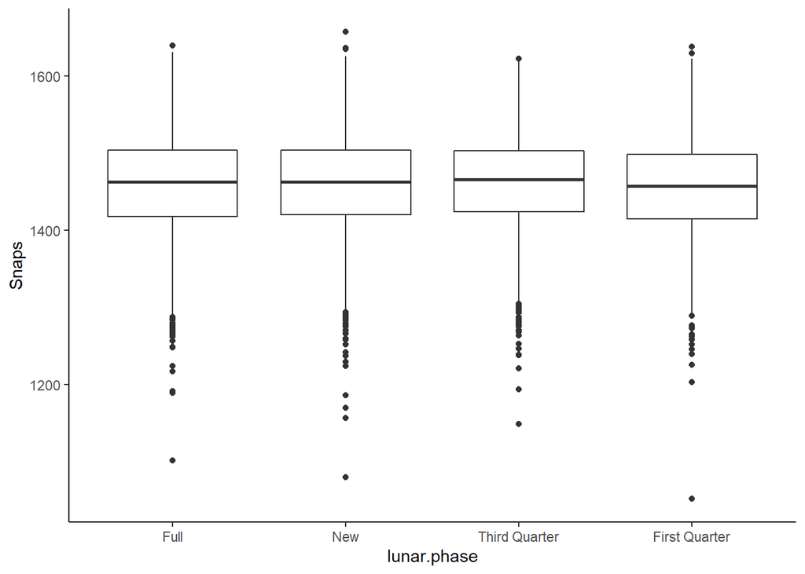

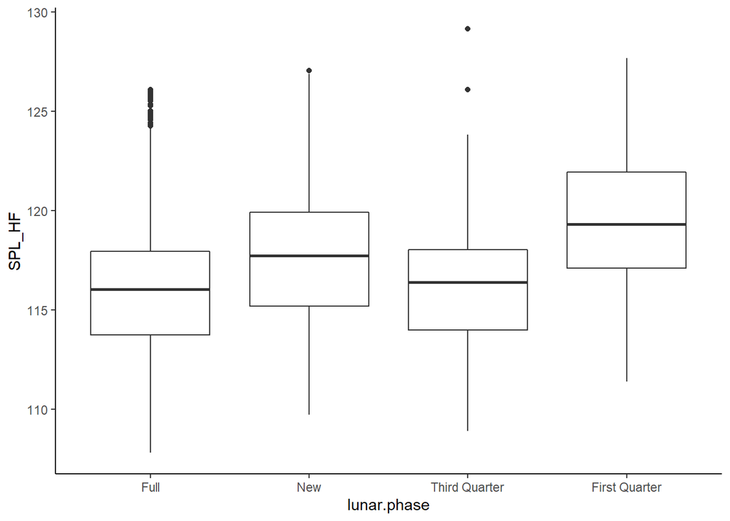

Snaps do not change in frequency with each of the lunar phases… although I am including daytime recordings here too.

HF SPL is higher during new moons and first quarter moons. - similar finding to those in Staaterman 2014.

### High Frequency (Only night recordings)

**Subsetting only night recordings here**

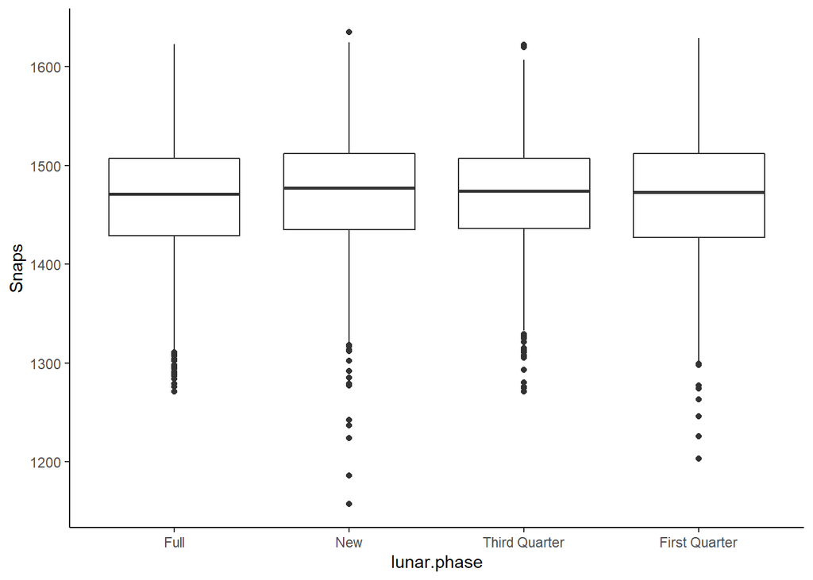

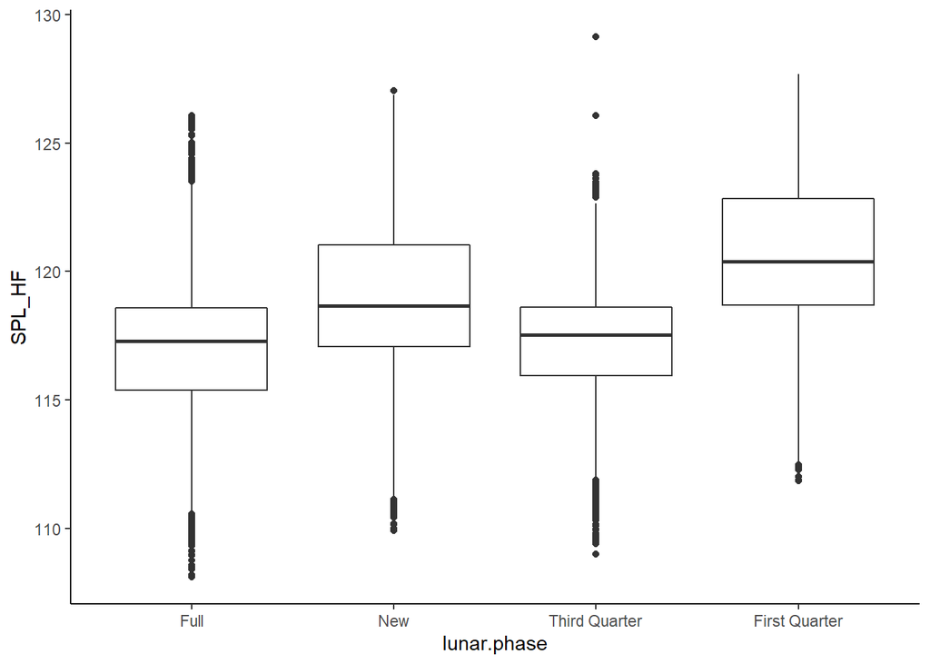

This only seems to have shifted the y axis up, not suprisingly as we know HF SPL is higher at night.

There is still no difference in snaps, even just subsetting the night time recordings

The difference isn’t obviously changed in HF SPL.

### Low Frequency

**Note** All first quarter moon phases are from 2018 and 2018 only. All other moon phases are from 2017.

**Lit Check** Staaterman 2014 - Quietest during full moon and loudest during new moon at reefs in Hawaii and Florida

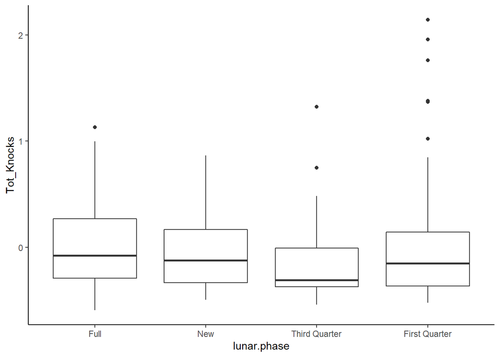

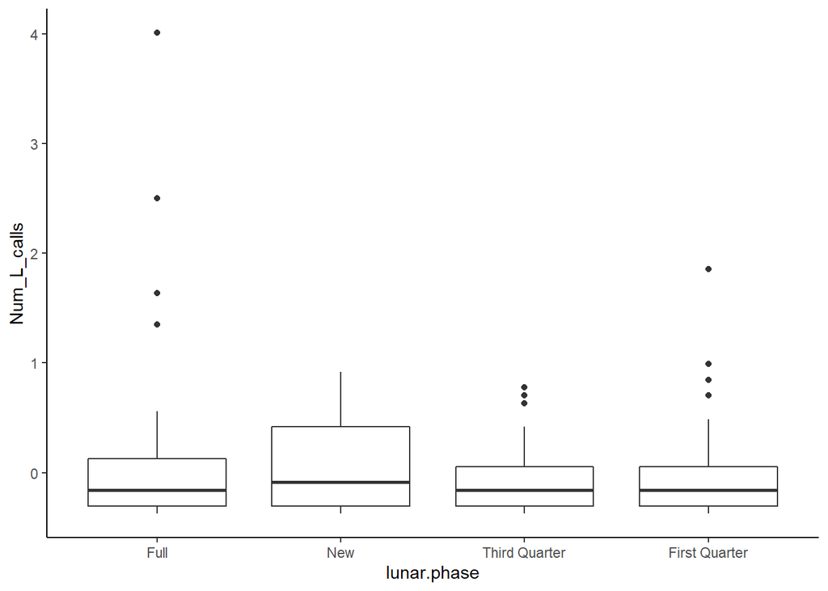

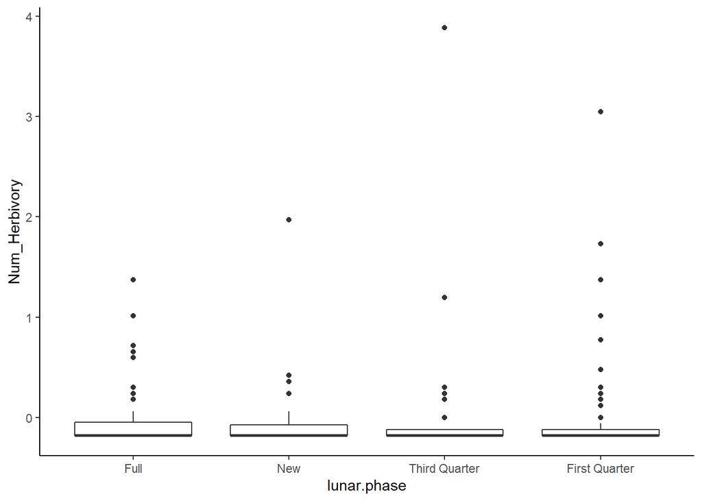

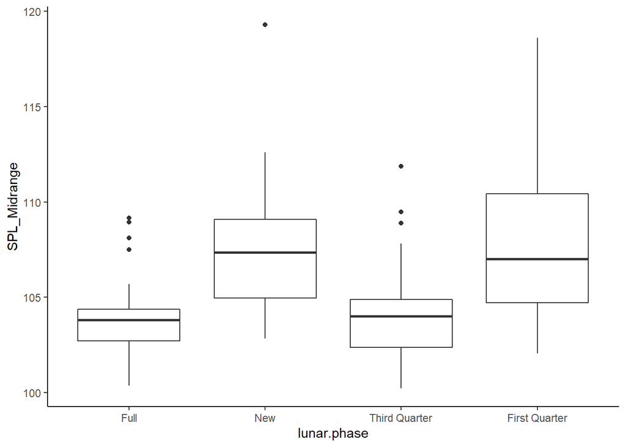

### Low Frequency (Only 03:00 and 21:00 recordings)

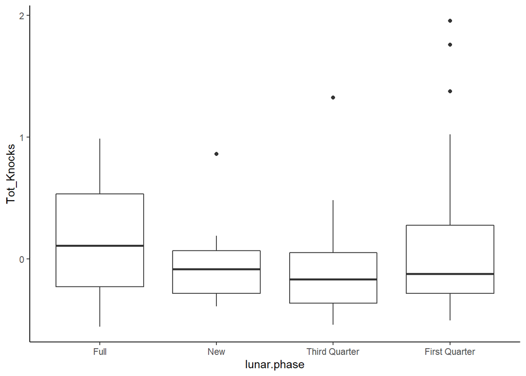

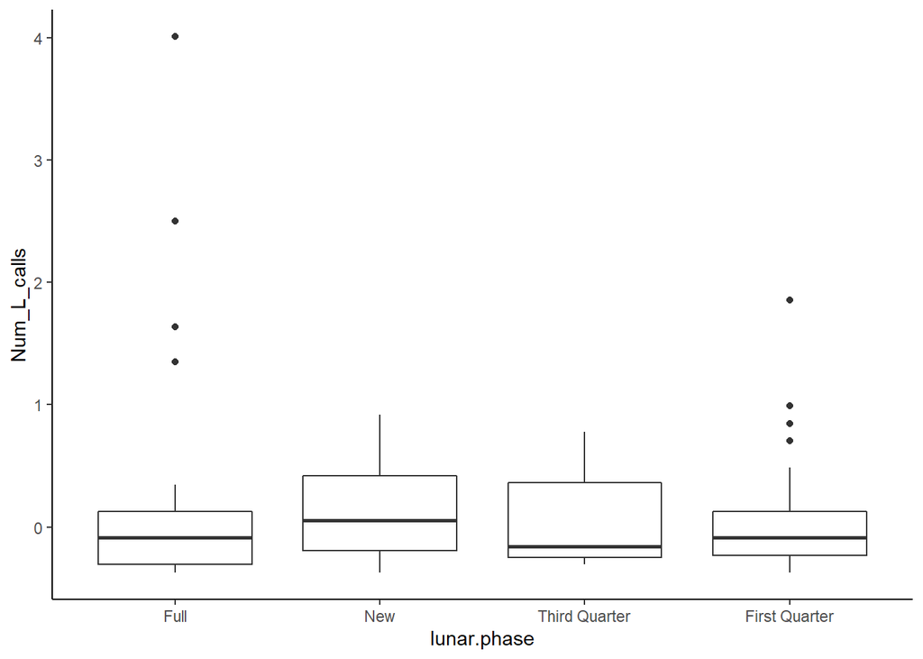

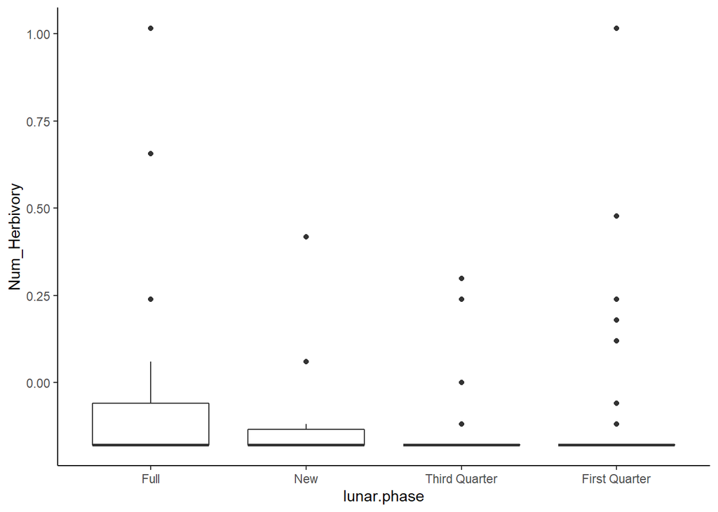

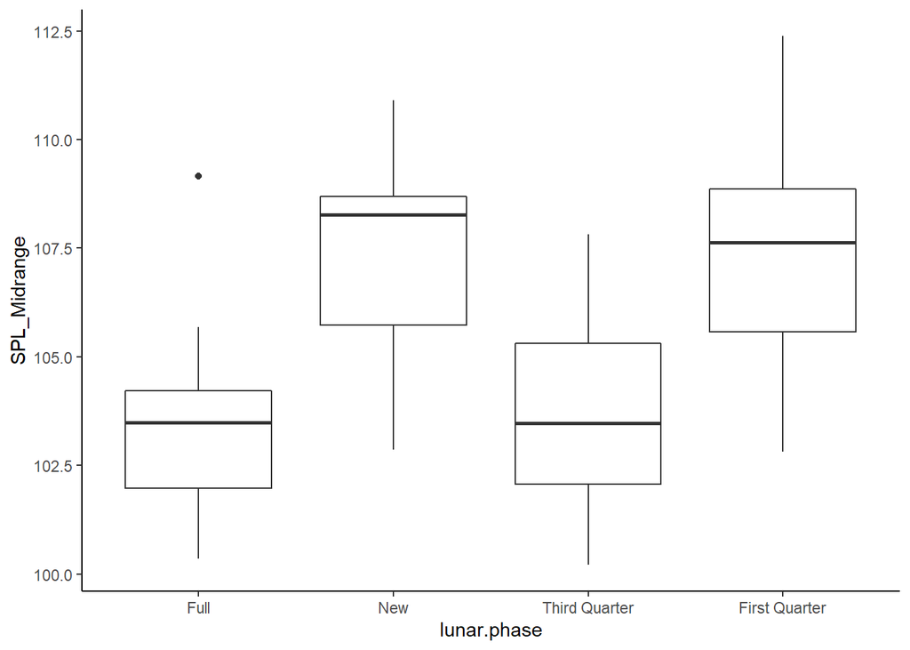

Full moon appears to have more knocks when I subset for only night. However, there is still alot of overlap.

In the MF, SPL appears to be a bit lower, due to some outliers being removed. The same pattern of high SPL occurs in the new and first quarter moons here, matching what we see in the high frequencies.

## ACI

**Lit Check** - Staaterman 2014 - LF ACI had 2 peaks per lunar day - during quarter moon and new moon - at one of their sites but not the other

### High Frequency

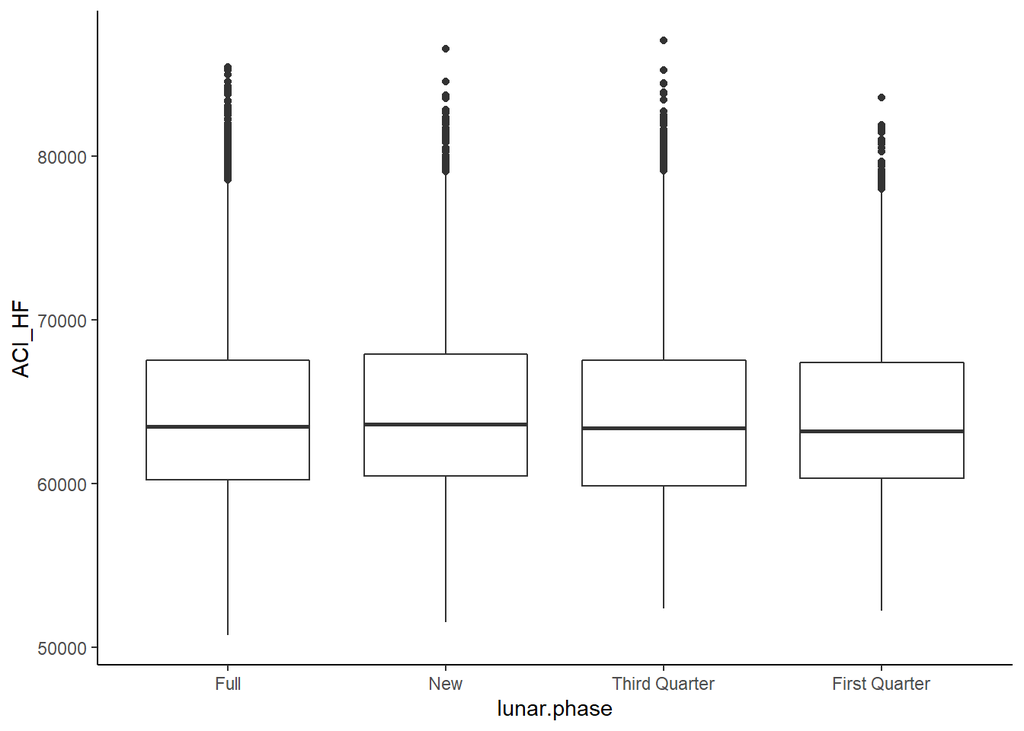

**Night Recordings Only**

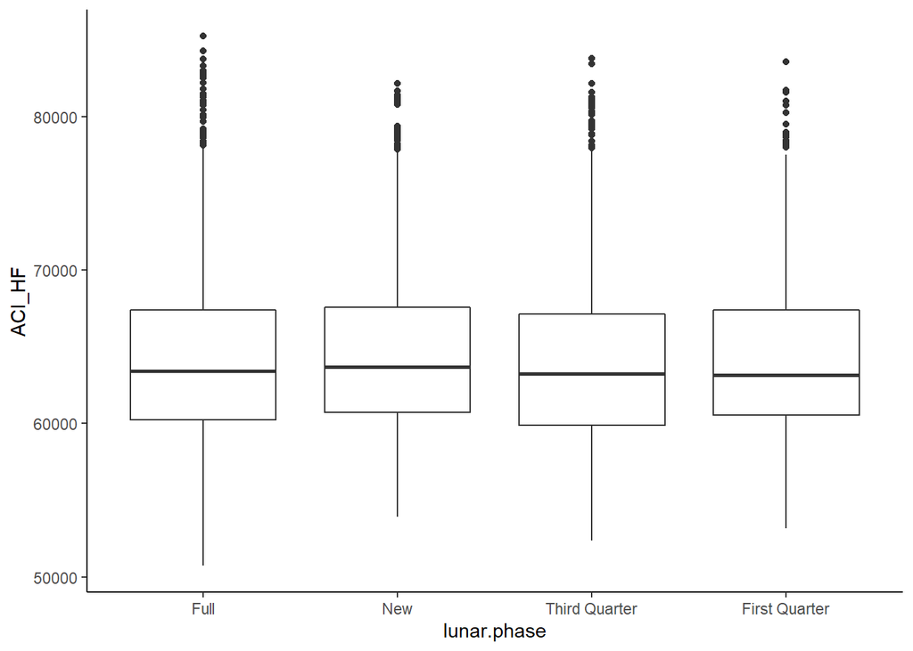

### Low Frequency

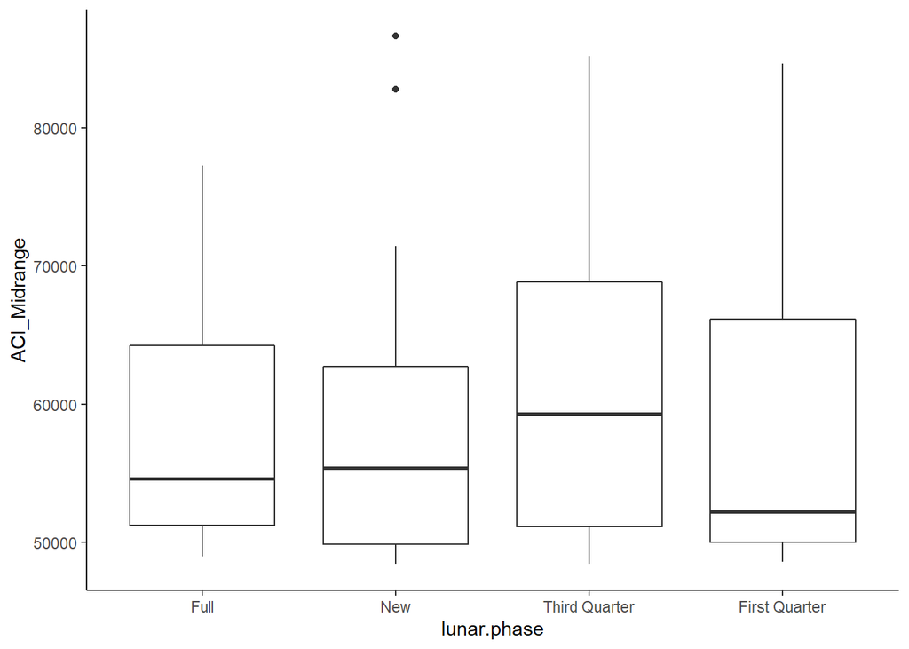

**Night Recordings Only**

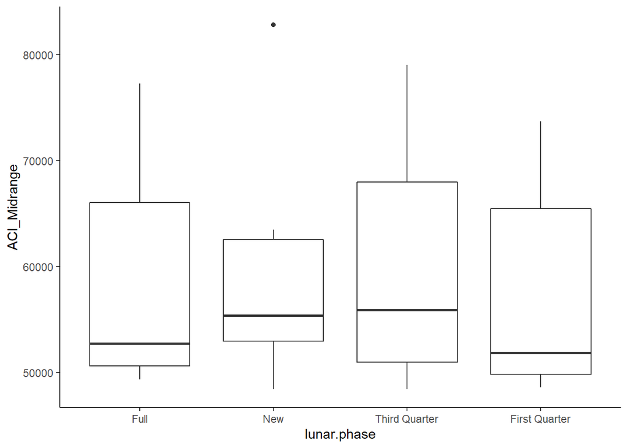

HF ACI doesn’t seem to change at all dependent on the moon phase

LF ACI “peaks” in the third quarter? Which is not what the literature supports. – when I subset just at night that peak disappears.